# transition_statesの機能

### バーチャートレースによる可視化

続いて、出現回数が多い順にバーが入れ替わるバーチャートレース(Bar Chart Race)を作成します。

各試行における出目の合計の順位を追加します。

```r
# ランク付け
rank_df <- count_df %>%
  dplyr::group_by(n) %>% # グループ化
  dplyr::mutate(ranking = dplyr::row_number(-count)) %>% # ランキング列を追加
  dplyr::ungroup() # グループ化の解除

# 10回目時点の結果
rank_df %>%
  dplyr::filter(n >= 10)
```

```
## # A tibble: 126 x 4
##        n v     count ranking
##    <dbl> <fct> <dbl>   <int>
##  1    10 1         1       4
##  2    10 2         0       5
##  3    10 3         3       2
##  4    10 4         4       1
##  5    10 5         0       6
##  6    10 6         2       3
##  7    11 1         1       4
##  8    11 2         0       6
##  9    11 3         3       2
## 10    11 4         4       1
## # ... with 116 more rows
```

`row_number()`で、昇順に整数を割り当てられます。ここでは、試行ごとに割り当てたいので`n`列でグループ化して、出現回数`count`列が多い順に割り当てたいのでマイナス`-`を付けて大小関係を入れ変えています。

棒グラフを描画します。

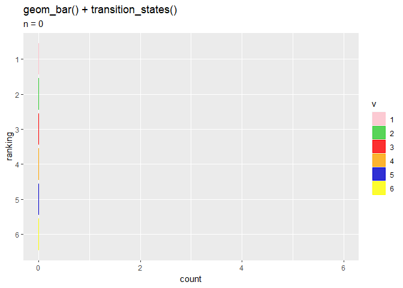

```r
# バーチャートレースを作成
anim <- ggplot(rank_df, aes(x = ranking, y = count, fill = v, color = v)) +
  geom_bar(stat = "identity", width = 0.9, alpha = 0.8) + # 棒グラフ
  gganimate::transition_states(states = n, transition_length = d) + # フレーム
  coord_flip() + # 軸の入れ変え
  scale_x_reverse(breaks = 1:V, minor_breaks = FALSE) + # x軸を反転
  scale_fill_manual(values = c("pink", "limegreen", "red", "orange", "mediumblue", "yellow")) + # バーの色:(不必要)
  scale_color_manual(values = c("pink", "limegreen", "red", "orange", "mediumblue", "yellow")) + # 枠線の色:(不必要)
  labs(title = "geom_bar() + transition_states()",
       subtitle = "n = {closest_state}")

# gif画像を作成
gganimate::animate(plot = anim, nframes = N*d, fps = d)
```

`x`軸(軸を入れ変えているので縦軸)に出現回数の順位`ranking`列を指定して、順位に応じてバーを入れ替えます。

ヒートマップを描画する関数`geom_tile()`でも作成できます。  
`geom_tile()`を使った棒グラフの作図について確認しておきます。

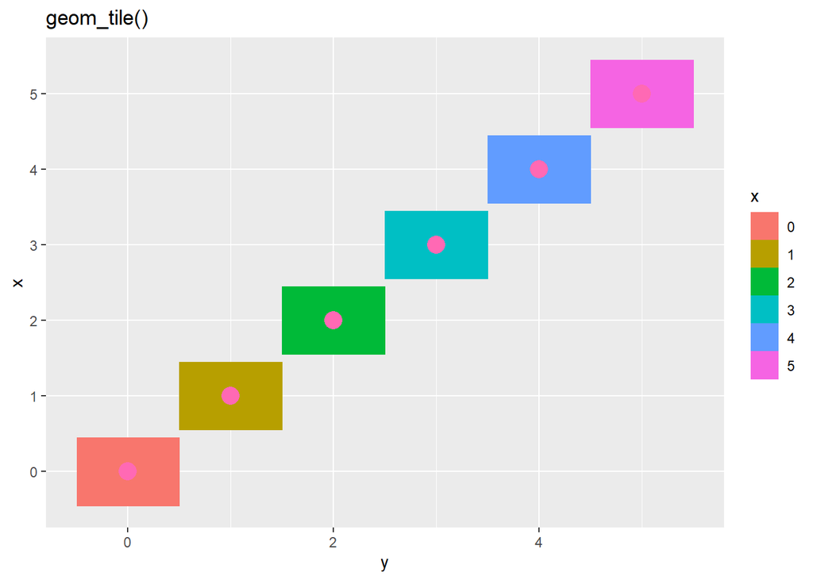

```r
# 引数の確認
ggplot(df, aes(x = x, y = y)) +
  geom_tile(aes(height = 1, fill = as.factor(x), color = as.factor(x)),
            width = 0.9) + # 棒グラフの代用
  geom_point(size = 5, color = "hotpink") + # 散布図
  coord_flip() + # 軸の入れ変え
  scale_x_continuous(breaks = df[["x"]], minor_breaks = FALSE) + # x軸目盛
  labs(title = "geom_tile()",
       y = "y", fill = "x", color = "x")
```

y軸の引数`y`に指定した値を中心に、高さの引数`height`に指定したサイズのバーが描画されます。軸を入れ替えているので高さは横方向の長さのことです。  
この図では`heigth = 1`としたので、各データのy軸の値(ピンク色の点)を中心に、左右に`0.5`ずつ伸びてバーのサイズが`1`になっているのを確認できます。

そこで、指定したい値の半分(`y / 2`)を`y`引数に指定して、実際の値(`y`)を`height`引数に指定することで、`0`から`y`までのバーを描画できます。

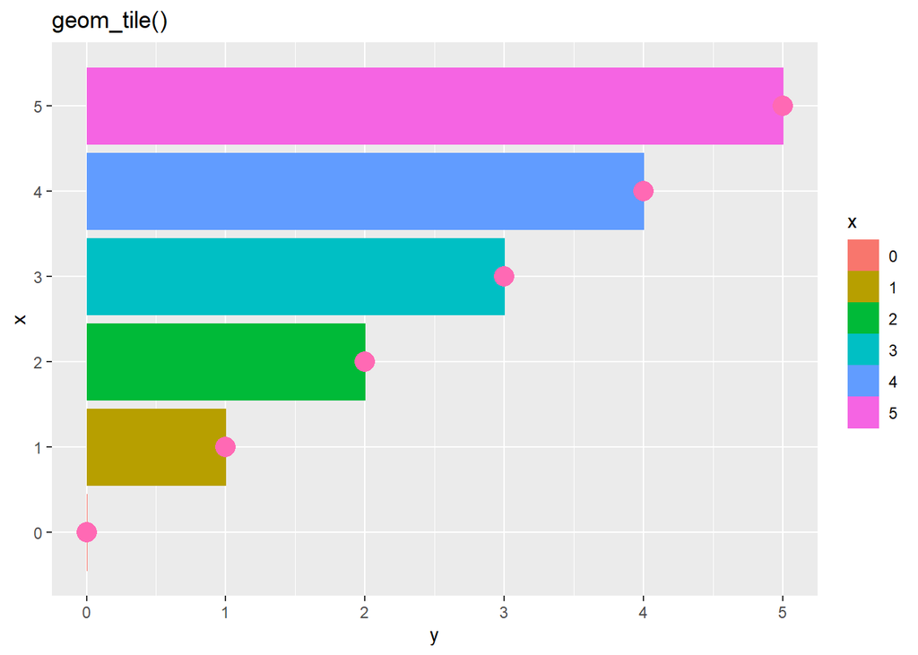

```r
# 棒グラフの代用を作成
ggplot(df, aes(x = x)) +
  geom_tile(aes(y = y / 2, height = y, fill = as.factor(x), color = as.factor(x)),
            width = 0.9) + # 棒グラフの代用
  geom_point(aes(y = y), size = 5, color = "hotpink") + # 散布図
  coord_flip() + # 軸の入れ変え
  scale_x_continuous(breaks = df[["x"]], minor_breaks = FALSE) + # x軸目盛
  labs(title = "geom_tile()",
       y = "y", fill = "x", color = "x")
```

各データのy軸の値(ピンク色の点)までの棒グラフを描画できました。

バーチャートレースを作成します。

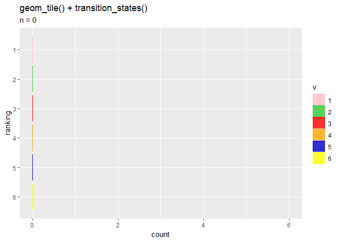

```r
# バーチャートレースを作成
anim <- ggplot(rank_df, aes(x = ranking, y = count / 2, height = count, fill = v, color = v)) +
  geom_tile(width = 0.9, alpha = 0.8) + # 棒グラフの代用
  gganimate::transition_states(states = n, transition_length = d) + # フレーム
  coord_flip() + # 軸の入れ変え
  scale_x_reverse(breaks = 1:V, minor_breaks = FALSE) + # x軸を反転
  scale_fill_manual(values = c("pink", "limegreen", "red", "orange", "mediumblue", "yellow")) + # バーの色:(不必要)
  scale_color_manual(values = c("pink", "limegreen", "red", "orange", "mediumblue", "yellow")) + # 枠線の色:(不必要)
  labs(title = "geom_tile() + transition_states()",
       subtitle = "n = {closest_state}",
       y = "count")

# gif画像を作成
gganimate::animate(plot = anim, nframes = N*d, fps = d)
```

(`geom_tile()`を使っているのをいくつか見たのでやってみましたが、`geom_bar()`を使うよりどんな嬉しさがあるのでしょうか？)

以上で、`transition_states()`について確認しました。